# crupR-Vignette

Persia Akbari Omgba

Mantainer  
omgba@molgen.mpg.de

Verena Heinrich

Creator  
heinrich@molgen.mpg.de

Abstract

# Overview

Beyond that, *crupR* offers an additional function to summarize the single enhancers into super enhancers (`getSE()`), a function to visualise the condition-specific enhancer clusters (`plotSummary()`) and a function to export all the files produced by each *crupR* step as appropriate formats (i.e. bed, BigWig or bedGraph).

# Getting started

## What will I need?

In order to run *crupR*, you need ChIPseq experiments for the histone modifications H3K27ac, H3K4me1 and H3K4me3. Additionally, it is recommended to also inclue an input experiment for those experiments, however if these aren't available for some reason, you can run *crupR* without them. All the experiments need to be already aligned and indexed.

## Prepare the metaData file

After you prepared your ChIPseq files, you need to prepare the meta data frame. This data frame contains the paths to all the necessary bam files. It also contains further information about them, such as condition, replicate, histone modification and input file.

Let's look at the metaData frame for the example files. First, we'll need the paths to the bam files and input files.

```r
files <- c(system.file("extdata", "Condition1.H3K4me1.bam", package="crupR"),
           system.file("extdata", "Condition1.H3K4me3.bam", package="crupR"),
           system.file("extdata", "Condition1.H3K27ac.bam", package="crupR"),
           system.file("extdata", "Condition2.H3K4me1.bam", package="crupR"),
           system.file("extdata", "Condition2.H3K4me3.bam", package="crupR"),
           system.file("extdata", "Condition2.H3K27ac.bam", package="crupR"))

inputs <- c(rep(system.file("extdata", "Condition1.Input.bam", package="crupR"), 3), rep(system.file("extdata", "Condition2.Input.bam", package="crupR"), 3))
```

Now we can build the meta data frame by adding the information about the hinstone modification, condition and replicate for each file. As there exists only one sample per condition, all of the files get replicate "1".

```r
metaData <- data.frame(HM = rep(c("H3K4me1","H3K4me3","H3K27ac"),2),
                       condition = c(1,1,1,2,2,2), replicate = c(1,1,1,1,1,1),
                       bamFile = files, inputFile = inputs)

metaData
```

```
#>        HM condition replicate
#> 1 H3K4me1         1         1
#> 2 H3K4me3         1         1
#> 3 H3K27ac         1         1
#> 4 H3K4me1         2         1
#> 5 H3K4me3         2         1
#> 6 H3K27ac         2         1
#>                                                                                    bamFile
#> 1 /scratch/local/RtmpAcN0le/temp_libpath126515e7fbe1f/crupR/extdata/Condition1.H3K4me1.bam
#> 2 /scratch/local/RtmpAcN0le/temp_libpath126515e7fbe1f/crupR/extdata/Condition1.H3K4me3.bam
#> 3 /scratch/local/RtmpAcN0le/temp_libpath126515e7fbe1f/crupR/extdata/Condition1.H3K27ac.bam
#> 4 /scratch/local/RtmpAcN0le/temp_libpath126515e7fbe1f/crupR/extdata/Condition2.H3K4me1.bam
#> 5 /scratch/local/RtmpAcN0le/temp_libpath126515e7fbe1f/crupR/extdata/Condition2.H3K4me3.bam
#> 6 /scratch/local/RtmpAcN0le/temp_libpath126515e7fbe1f/crupR/extdata/Condition2.H3K27ac.bam
#>                                                                                inputFile
#> 1 /scratch/local/RtmpAcN0le/temp_libpath126515e7fbe1f/crupR/extdata/Condition1.Input.bam
#> 2 /scratch/local/RtmpAcN0le/temp_libpath126515e7fbe1f/crupR/extdata/Condition1.Input.bam
#> 3 /scratch/local/RtmpAcN0le/temp_libpath126515e7fbe1f/crupR/extdata/Condition1.Input.bam
#> 4 /scratch/local/RtmpAcN0le/temp_libpath126515e7fbe1f/crupR/extdata/Condition2.Input.bam
#> 5 /scratch/local/RtmpAcN0le/temp_libpath126515e7fbe1f/crupR/extdata/Condition2.Input.bam
#> 6 /scratch/local/RtmpAcN0le/temp_libpath126515e7fbe1f/crupR/extdata/Condition2.Input.bam
```

After creating the meta data frame, you are ready to run *crupR*.

# Run the *crupR* pipeline

## Step 0: Normalize the ChIPseq counts

*crupR* needs normalized ChIPseq counts for its prediction, so we offer an additional function to normalize the ChIPseq files beforehand. You need to normalize each ChIPseq files for each replicate of each condition, which means we need to run *crupR* twice for our example files. Please note, that *crupR* can only normalize bam files for the genomes mm9, mm10, hg19 and hg38.

```r
normalized_1 <- crupR::normalize(metaData = metaData, condition = 1, replicate = 1, genome = "mm10",
                                sequencing = "paired", cores = 2)
```

```
#>
#> --- List input parameter ---
#>
#>   ..all ChIPseq files exist:
#>   .. H3K4me1 experiment:  /scratch/local/RtmpAcN0le/temp_libpath126515e7fbe1f/crupR/extdata/Condition1.H3K4me1.bam
#>   .. H3K4me3 experiment:  /scratch/local/RtmpAcN0le/temp_libpath126515e7fbe1f/crupR/extdata/Condition1.H3K4me3.bam
#>   .. H3K27ac experiment:  /scratch/local/RtmpAcN0le/temp_libpath126515e7fbe1f/crupR/extdata/Condition1.H3K27ac.bam
#>   .. Input experiment(s):  /scratch/local/RtmpAcN0le/temp_libpath126515e7fbe1f/crupR/extdata/Condition1.Input.bam /scratch/local/RtmpAcN0le/temp_libpath126515e7fbe1f/crupR/extdata/Condition1.Input.bam /scratch/local/RtmpAcN0le/temp_libpath126515e7fbe1f/crupR/extdata/Condition1.Input.bam
#>   .. mapq:  10
#>   .. genome:  mm10
#>   .. sequencing:  paired
#>   .. cores:  2
#>
#>  >>> All done!
#>
#> --- Get information of ChIP-seq experiments ---
#>
#>
#>  >>> All done!
#>
#> --- Prepare the binned genome ---
#>
#>   ..get binned genome for mm10.. done.
#>   ..get prefix of chromosomes from  file /scratch/local/RtmpAcN0le/temp_libpath126515e7fbe1f/crupR/extdata/Condition1.H3K4me1.bam.. done.
#>   ..adjust prefix of chromosome names in binned genome.. done.
#>
#>  >>> All done!
#>
#> --- Get summarized counts from ChIP-seq experiments ---
#>
#>
#>  >>> All done!
#>
#> --- Normalize histone modifications by Input ---
#>
#>
#>  >>> All done!
#>
#> --- Create summarized data matrix ---
#>
#>   ..create matrix.. done.
#>   ..include log2 H3K4me1/H3K4me3 ratio.. done.
#> .. done.
#>
#>  >>> All done!
#>
#> --- Run time ---
#>
#>   ..1.379633 mins
#>
#>  >>> All done!
```

```r
normalized_2 <- crupR::normalize(metaData = metaData, condition = 2, replicate = 1, genome = "mm10",
                                sequencing = "paired", cores = 2)
```

```
#>
#> --- List input parameter ---
#>
#>   ..all ChIPseq files exist:
#>   .. H3K4me1 experiment:  /scratch/local/RtmpAcN0le/temp_libpath126515e7fbe1f/crupR/extdata/Condition2.H3K4me1.bam
#>   .. H3K4me3 experiment:  /scratch/local/RtmpAcN0le/temp_libpath126515e7fbe1f/crupR/extdata/Condition2.H3K4me3.bam
#>   .. H3K27ac experiment:  /scratch/local/RtmpAcN0le/temp_libpath126515e7fbe1f/crupR/extdata/Condition2.H3K27ac.bam
#>   .. Input experiment(s):  /scratch/local/RtmpAcN0le/temp_libpath126515e7fbe1f/crupR/extdata/Condition2.Input.bam /scratch/local/RtmpAcN0le/temp_libpath126515e7fbe1f/crupR/extdata/Condition2.Input.bam /scratch/local/RtmpAcN0le/temp_libpath126515e7fbe1f/crupR/extdata/Condition2.Input.bam
#>   .. mapq:  10
#>   .. genome:  mm10
#>   .. sequencing:  paired
#>   .. cores:  2
#>
#>  >>> All done!
#>
#> --- Get information of ChIP-seq experiments ---
#>
#>
#>  >>> All done!
#>
#> --- Prepare the binned genome ---
#>
#>   ..get binned genome for mm10.. done.
#>   ..get prefix of chromosomes from  file /scratch/local/RtmpAcN0le/temp_libpath126515e7fbe1f/crupR/extdata/Condition2.H3K4me1.bam.. done.
#>   ..adjust prefix of chromosome names in binned genome.. done.
#>
#>  >>> All done!
#>
#> --- Get summarized counts from ChIP-seq experiments ---
#>
#>
#>  >>> All done!
#>
#> --- Normalize histone modifications by Input ---
#>
#>
#>  >>> All done!
#>
#> --- Create summarized data matrix ---
#>
#>   ..create matrix.. done.
#>   ..include log2 H3K4me1/H3K4me3 ratio.. done.
#> .. done.
#>
#>  >>> All done!
#>
#> --- Run time ---
#>
#>   ..1.154597 mins
#>
#>  >>> All done!
```

The output of `normalize()` should be a list of length 2 containing the meta data of the samples that were normalized and a GRanges object containing the normalized ChIPseq counts for the binned genome of your choice.

```r
normalized_1$metaData
```

```
#>        HM condition replicate
#> 1 H3K4me1         1         1
#> 2 H3K4me3         1         1
#> 3 H3K27ac         1         1
#>                                                                                    bamFile
#> 1 /scratch/local/RtmpAcN0le/temp_libpath126515e7fbe1f/crupR/extdata/Condition1.H3K4me1.bam
#> 2 /scratch/local/RtmpAcN0le/temp_libpath126515e7fbe1f/crupR/extdata/Condition1.H3K4me3.bam
#> 3 /scratch/local/RtmpAcN0le/temp_libpath126515e7fbe1f/crupR/extdata/Condition1.H3K27ac.bam
#>                                                                                inputFile
#> 1 /scratch/local/RtmpAcN0le/temp_libpath126515e7fbe1f/crupR/extdata/Condition1.Input.bam
#> 2 /scratch/local/RtmpAcN0le/temp_libpath126515e7fbe1f/crupR/extdata/Condition1.Input.bam
#> 3 /scratch/local/RtmpAcN0le/temp_libpath126515e7fbe1f/crupR/extdata/Condition1.Input.bam
```

```r
normalized_1$normalized
```

```
#> GRanges object with 26337756 ranges and 4 metadata columns:
#>              seqnames              ranges strand |   H3K4me1   H3K4me3
#>                 <Rle>           <IRanges>  <Rle> | <numeric> <numeric>
#>          [1]     chr1               1-100      * |         0         0
#>          [2]     chr1             101-200      * |         0         0
#>          [3]     chr1             201-300      * |         0         0
#>          [4]     chr1             301-400      * |         0         0
#>          [5]     chr1             401-500      * |         0         0
#>          ...      ...                 ...    ... .       ...       ...
#>   [26337752]     chrX 171030701-171030800      * |         0         0
#>   [26337753]     chrX 171030801-171030900      * |         0         0
#>   [26337754]     chrX 171030901-171031000      * |         0         0
#>   [26337755]     chrX 171031001-171031100      * |         0         0
#>   [26337756]     chrX 171031101-171031200      * |         0         0
#>                H3K27ac              ratio
#>              <numeric>          <numeric>
#>          [1]         0 -0.228070777344398
#>          [2]         0 -0.228070777344398
#>          [3]         0 -0.228070777344398
#>          [4]         0 -0.228070777344398
#>          [5]         0 -0.228070777344398
#>          ...       ...                ...
#>   [26337752]         0 -0.228070777344398
#>   [26337753]         0 -0.228070777344398
#>   [26337754]         0 -0.228070777344398
#>   [26337755]         0 -0.228070777344398
#>   [26337756]         0 -0.228070777344398
#>   -------
#>   seqinfo: 20 sequences from mm10 genome
```

Per default, the files are input normalized. However, in case input experiments were not conducted or input files are not available for other reasons, *crupR* also offers the possibility of an input free mode. The output file will have the same structure.

```r
normalized_1_inputFree <- crupR::normalize(metaData = metaData, condition = 1, replicate = 1,
                                          genome = "mm10", sequencing = "paired", input.free = TRUE, cores = 2)
```

```
#>
#> --- List input parameter ---
#>
#>   ..all ChIPseq files exist:
#>   .. H3K4me1 experiment:  /scratch/local/RtmpAcN0le/temp_libpath126515e7fbe1f/crupR/extdata/Condition1.H3K4me1.bam
#>   .. H3K4me3 experiment:  /scratch/local/RtmpAcN0le/temp_libpath126515e7fbe1f/crupR/extdata/Condition1.H3K4me3.bam
#>   .. H3K27ac experiment:  /scratch/local/RtmpAcN0le/temp_libpath126515e7fbe1f/crupR/extdata/Condition1.H3K27ac.bam
#>   .. Running the input free mode
#>   .. mapq:  10
#>   .. genome:  mm10
#>   .. sequencing:  paired
#>   .. cores:  2
#>
#>  >>> All done!
#>
#> --- Get information of ChIP-seq experiments ---
#>
#>
#>  >>> All done!
#>
#> --- Prepare the binned genome ---
#>
#>   ..get binned genome for mm10.. done.
#>   ..get prefix of chromosomes from  file /scratch/local/RtmpAcN0le/temp_libpath126515e7fbe1f/crupR/extdata/Condition1.H3K4me1.bam.. done.
#>   ..adjust prefix of chromosome names in binned genome.. done.
#>
#>  >>> All done!
#>
#> --- Get summarized counts from ChIP-seq experiments ---
#>
#>
#>  >>> All done!
#>
#> --- Create summarized data matrix ---
#>
#>   ..create matrix.. done.
#>   ..include log2 H3K4me1/H3K4me3 ratio.. done.
#> .. done.
#>
#>  >>> All done!
#>
#> --- Run time ---
#>
#>   ..1.754909 mins
#>
#>  >>> All done!
```

```r
normalized_1_inputFree$metaData
```

```
#>        HM condition replicate
#> 1 H3K4me1         1         1
#> 2 H3K4me3         1         1
#> 3 H3K27ac         1         1
#>                                                                                    bamFile
#> 1 /scratch/local/RtmpAcN0le/temp_libpath126515e7fbe1f/crupR/extdata/Condition1.H3K4me1.bam
#> 2 /scratch/local/RtmpAcN0le/temp_libpath126515e7fbe1f/crupR/extdata/Condition1.H3K4me3.bam
#> 3 /scratch/local/RtmpAcN0le/temp_libpath126515e7fbe1f/crupR/extdata/Condition1.H3K27ac.bam
#>                                                                                inputFile
#> 1 /scratch/local/RtmpAcN0le/temp_libpath126515e7fbe1f/crupR/extdata/Condition1.Input.bam
#> 2 /scratch/local/RtmpAcN0le/temp_libpath126515e7fbe1f/crupR/extdata/Condition1.Input.bam
#> 3 /scratch/local/RtmpAcN0le/temp_libpath126515e7fbe1f/crupR/extdata/Condition1.Input.bam
```

```r
normalized_1_inputFree$normalized
```

```
#> GRanges object with 26337756 ranges and 4 metadata columns:
#>              seqnames              ranges strand |   H3K4me1   H3K4me3
#>                 <Rle>           <IRanges>  <Rle> | <integer> <integer>
#>          [1]     chr1               1-100      * |         0         0
#>          [2]     chr1             101-200      * |         0         0
#>          [3]     chr1             201-300      * |         0         0
#>          [4]     chr1             301-400      * |         0         0
#>          [5]     chr1             401-500      * |         0         0
#>          ...      ...                 ...    ... .       ...       ...
#>   [26337752]     chrX 171030701-171030800      * |         0         0
#>   [26337753]     chrX 171030801-171030900      * |         0         0
#>   [26337754]     chrX 171030901-171031000      * |         0         0
#>   [26337755]     chrX 171031001-171031100      * |         0         0
#>   [26337756]     chrX 171031101-171031200      * |         0         0
#>                H3K27ac     ratio
#>              <integer> <numeric>
#>          [1]         0         0
#>          [2]         0         0
#>          [3]         0         0
#>          [4]         0         0
#>          [5]         0         0
#>          ...       ...       ...
#>   [26337752]         0         0
#>   [26337753]         0         0
#>   [26337754]         0         0
#>   [26337755]         0         0
#>   [26337756]         0         0
#>   -------
#>   seqinfo: 20 sequences from mm10 genome
```

## Step 1: Predict active enhancers with crupR

Now, the normalized ChIPseq counts can be used to predict the occurrence of active enhancers on the genome of your choice. Again, you'll have to run this step for each replicate of each condition, basically for each output of the normalization step.

```r
prediction_1 <- crupR::getEnhancers(data = normalized_1, cores = 2)
```

```
#>
#> --- List input parameter ---
#>
#>   .. classifier:  default
#>   .. distance:  12500
#>   .. cutoff:  0.5
#>   .. cores:  2
#>
#>  >>> All done!
#>
#> --- Get classifier and empirical distribution function ---
#>
#>
#>  >>> All done!
#>
#> --- Quantile normalize summarized data matrix ---
#>
#>   ..quantile normalize counts for feature H3K27ac.. done.
#>   ..quantile normalize counts for feature H3K4me1.. done.
#>   ..quantile normalize counts for feature H3K4me3.. done.
#>   ..quantile normalize counts for feature ratio.. done.
#>
#>  >>> All done!
#>
#> --- Extend data matrix (+/- 5 bins) ---
#>
#>   ..create extended data matrix.. done.
#>
#>  >>> All done!
#>
#> --- Get enhancer probabilities for each bin ---
#>
#>
#>  >>> All done!
#>
#> --- Run time ---
#>
#>   ..1.444062 mins
#>
#>  >>> All done!
```

```r
prediction_2 <- crupR::getEnhancers(data = normalized_2, cores = 2)
```

```
#>
#> --- List input parameter ---
#>
#>   .. classifier:  default
#>   .. distance:  12500
#>   .. cutoff:  0.5
#>   .. cores:  2
#>
#>  >>> All done!
#>
#> --- Get classifier and empirical distribution function ---
#>
#>
#>  >>> All done!
#>
#> --- Quantile normalize summarized data matrix ---
#>
#>   ..quantile normalize counts for feature H3K27ac.. done.
#>   ..quantile normalize counts for feature H3K4me1.. done.
#>   ..quantile normalize counts for feature H3K4me3.. done.
#>   ..quantile normalize counts for feature ratio.. done.
#>
#>  >>> All done!
#>
#> --- Extend data matrix (+/- 5 bins) ---
#>
#>   ..create extended data matrix.. done.
#>
#>  >>> All done!
#>
#> --- Get enhancer probabilities for each bin ---
#>
#>
#>  >>> All done!
#>
#> --- Run time ---
#>
#>   ..1.084631 mins
#>
#>  >>> All done!
```

Per default, this function uses a classifier consisting of two random forests to predict the probability of an bin being an active enhancer. This default classifier was trained on mESC data. It is also possible to use your own classifier if you wish to do so. In that case just run:

```r
prediction_1_own_class <- crupR::getEnhancers(data = normalized_1, classifier = "path/to/classifier", cores = 2)
```

However, you need to make sure that the directory contains two classifiers that predict the same events that the default random forests predict. That means one classifer has to classify active vs. inactive genomic ranges, while the other one must classify enhancer vs active promoter regions. Additionally, the two classifiers also need to be named "active_vs_inactive.rds" and "enhancer_vs_active_promoter.rds" respectively. This is necessary so that *crupR* is able to accurately identify them.

The output of this step is a list containing the truncated meta data file containing the information about the respective condition and replicate and a GRanges file containing the the binned genome with the enhancer prediction values for each bin.

## Step 1.5: Find enhancer peaks and super enhancers with crupR

*crupR* offers the `getSE()` function as an additional step after the enhancer prediction. Enhancers that are in close proximity are summarized into super enhancers during this step. However, this step does not solely return these super enhancers, but also all enhancer peak calls.

`getSE()` uses the output of the last step (enhancerPrediction), meaning the list with the meta data and the GRanges object, as input. There are two additnal input parameters to specifify the process: * "cutoff": a threshold for the prediction values of the peaks (default: 0.5). The higher the cutoff, the stricter the peak calling process. * "distance": the maximimum distance (bp) between peaks for clustering into superenhancers (default:12500). The lower the distance, the closer the single enhancers or peaks need to be in order to be clustered together. A short example:

```r
se <- crupR::getSE(data = prediction_2, cores = 2)
```

```
#>
#> --- Call enhancer peaks and cluster ---
#>
#>   ..define single enhancers   ..2 single enhancer peak(s) found.. done.
#>   ..define cluster of enhancer peaks  ..1 enhancer cluster found.. done.
#>
#>  >>> All done!
```

```r
se_strict <- crupR::getSE(data = prediction_2, cutoff = 0.7, cores = 2)
```

```
#>
#> --- Call enhancer peaks and cluster ---
#>
#>   ..define single enhancers   ..2 single enhancer peak(s) found.. done.
#>   ..define cluster of enhancer peaks  ..1 enhancer cluster found.. done.
#>
#>  >>> All done!
```

```r
se_close <- crupR::getSE(data = prediction_2, distance=10000, cores = 2)
```

```
#>
#> --- Call enhancer peaks and cluster ---
#>
#>   ..define single enhancers   ..2 single enhancer peak(s) found.. done.
#>   ..define cluster of enhancer peaks  ..1 enhancer cluster found.. done.
#>
#>  >>> All done!
```

This step is not necessary for the next ones and can be skipped if one isn't interested in the peak calls or peak clusters.

## Step 2: Find conditon-specific enhancer clusters

In the second workflow step, the *crupR* function `getDynamics()` defines dynamic enhancer regions by applying a Kolmogorov-Smirnov test directly on the enhancer probabilities in a pairwise manner.

Before running the actual function, a small preparation step is necessary. The output lists of the previous step are used as input, but need to be contained by one file. Thus, they must all be put into one list.

```r
predictions <- list(prediction_1, prediction_2)
```

```r
clusters <- crupR::getDynamics(data = predictions, cores = 2)
```

```
#>
#> --- List input parameter ---
#>
#>   .. w_0:  0.5
#>   .. threshold:  0.05
#>   .. cores:  2
#>   .. window:  10
#>
#>  >>> All done!
#>
#> --- Read enhancer probabilites for all samples and conditions ---
#>
#>
#>  >>> All done!
#>
#> --- Calculate (pairwise) empirical p-values ---
#>
#>
#>  >>> All done!
#>
#> --- Get condition-specific enhancer peaks ---
#>
#>   ..build significance peak pattern.. done.
#>   ..combine peaks by significance pattern.. done.
#>   ..assign clusters.. done.
#>
#> --- Run time ---
#>
#>   ..43.4332 secs
#>
#>  >>> All done!
```

The output of this step is a list containing the complete meta data file and the condition-specific clusters in a GRanges object.

```r
#meta data
clusters$metaData
```

```
#>        HM condition replicate
#> 1 H3K4me1         1         1
#> 2 H3K4me3         1         1
#> 3 H3K27ac         1         1
#> 4 H3K4me1         2         1
#> 5 H3K4me3         2         1
#> 6 H3K27ac         2         1
#>                                                                                    bamFile
#> 1 /scratch/local/RtmpAcN0le/temp_libpath126515e7fbe1f/crupR/extdata/Condition1.H3K4me1.bam
#> 2 /scratch/local/RtmpAcN0le/temp_libpath126515e7fbe1f/crupR/extdata/Condition1.H3K4me3.bam
#> 3 /scratch/local/RtmpAcN0le/temp_libpath126515e7fbe1f/crupR/extdata/Condition1.H3K27ac.bam
#> 4 /scratch/local/RtmpAcN0le/temp_libpath126515e7fbe1f/crupR/extdata/Condition2.H3K4me1.bam
#> 5 /scratch/local/RtmpAcN0le/temp_libpath126515e7fbe1f/crupR/extdata/Condition2.H3K4me3.bam
#> 6 /scratch/local/RtmpAcN0le/temp_libpath126515e7fbe1f/crupR/extdata/Condition2.H3K27ac.bam
#>                                                                                inputFile
#> 1 /scratch/local/RtmpAcN0le/temp_libpath126515e7fbe1f/crupR/extdata/Condition1.Input.bam
#> 2 /scratch/local/RtmpAcN0le/temp_libpath126515e7fbe1f/crupR/extdata/Condition1.Input.bam
#> 3 /scratch/local/RtmpAcN0le/temp_libpath126515e7fbe1f/crupR/extdata/Condition1.Input.bam
#> 4 /scratch/local/RtmpAcN0le/temp_libpath126515e7fbe1f/crupR/extdata/Condition2.Input.bam
#> 5 /scratch/local/RtmpAcN0le/temp_libpath126515e7fbe1f/crupR/extdata/Condition2.Input.bam
#> 6 /scratch/local/RtmpAcN0le/temp_libpath126515e7fbe1f/crupR/extdata/Condition2.Input.bam
```

```r
#clusters
clusters$sumFile
```

```
#> GRanges object with 1 range and 4 metadata columns:
#>       seqnames            ranges strand |     pattern   cond1_1   cond2_1
#>          <Rle>         <IRanges>  <Rle> | <character> <numeric> <numeric>
#>   [1]     chr8 26842401-26847500      * |          10     0.027     0.441
#>       cluster
#>        <list>
#>   [1]     c_1
#>   -------
#>   seqinfo: 20 sequences from mm10 genome
```

### The parameters

`getDynamics()` possesses a rather extensive set of paremeters that are not as self-explanatpry as the ones of the previous steps. Therefore, this subsection offers more in detail explanations of their use.

*w_0: Since comparing all the enhancer regions between two conditions to find siginificant clusters would be too expensive, a filter step was included. In this step, enhancers whose normalized prediction means did not differ strongly enough were discared before running the actual test. w_0 is the minimum difference between the means in order to be considered for the comparison. The default is 0.5.

*threshold: The threshold value for the p-values that are computed during the clustering process. The default is 0.05.

*window: Number of bins +/- the current bin that should be included when calculating the p-values. The default is 10. However, the range for values that produce enhancer clusters of a realistic size is limited to [2, 30].

*cores: Number of cores that should be used for parallel processing. The default is 1.

### Understanding the patterns of the clusters

The clusters are named after their sizes. Meaning cluster 1 st the biggest cluster, cluster 2 the second biggest and so on. However, additionaly to just the cluster names `getDynamics()` also returns the so called patterns of the clusters. These are simple binary codes:

```r
clusters$sumFile$pattern
```

```
#> [1] "10"
```

The patterns return the result of each pairwise comparison inside of a cluster. For n conditions $c_0, c_1, ..., c_n$ there are $k = {n \choose 2}$ possible pairwise comparisons $(c_0,c_1), (c_0, c_2), ..., (c_{n-1}, c_n)$. In this case the enhancer activity values of the two conditions are compared. Each comparison $(c_i, c_j)$ ($i < j$) has two possible outcomes: Either the first condition ($c_i$) is less active or the second one is ($c_j$) (equality is not an option because regions without strong differences were already filtered). The pattern codes possess one bit per possible result of a comparison, which makes $2 * k$ bits. The first half, so the first k bits, describes the first outcomes ($c_i < c_j$) and the second half describes the second possible outcomes $c_i > c_j$ (for $i < j$). If one outcome is true, the bit is 1, otherwise it's 0. This means for a bit $b_x$ at spot x with $x \leq k$ (the bit is in the first half), the bit $b_{x+k}$ describes the complimentary outcome of the same comparison. It follows that they can never both be 1, because this would mean that both possible outcomes are true which is impossible.

Let's look at the example at hand: The test bam-files of *crupR* include 2 conditions $c_0, c_1$. This means, there is only ${2 \choose 2} = 1$ possible comparison $(c_0,c_1)$ and therefore 2 bits. The first bit $b_1$ signfifies wether or not $c_0 < c_1$ is true. The second bit $b_2$ signifies wether or not $c_0 > c_1$ is true. There are 4 possible patterns: 00, 01, 10 and 11. However, 00 and 11 are not valid options which leaves 01 and 10. In the cluster for 01, the enhancers are more active in the first condition. In the cluster for 10, the enhancers are more active in the second condition.

### Visualization of the clusters using `plotSummary()`

Let's take a look at the summary plot of the example files.

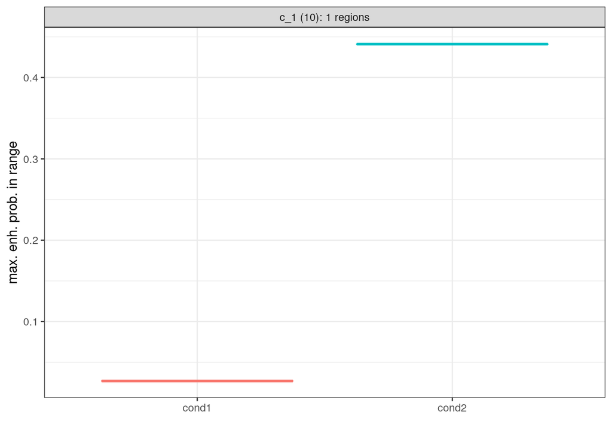

```r
crupR::plotSummary(clusters)
```

## Step 3: Find target genes of the condition-specific enhancer clusters

The last step in the pipeline is the identification of the target genes that get regulated by the condition-specific enhancer clusters found in the previous step.

### Gene expression counts

For the function `getTargets(()`the output of the step before is not sufficient. *crupR* requires additionally the gene expression counts for each condition and replicate all in one GRanges object. *crupR* offers such an expression file for the the example sets.

```r
expression <- readRDS(file = system.file("extdata", "expressions.rds", package="crupR"))
```

However, there is no in-built function that calculates the gene expression counts from RNAseq experiments. That means the user has to generate this file by themselves. Please make sure that the column names for the columns that contain the gene expression counts of each sample are the same as the column names of the columns that contain the enhancer probabilities of each sample, i.e. "cond1_1", "cond1_2", "cond2_1" and so on. Let's take a look at the given expression object:

```r
expression
```

```
#> GRanges object with 1028 ranges and 3 metadata columns:
#>             seqnames              ranges strand |     gene_id          cond1_1
#>                <Rle>           <IRanges>  <Rle> | <character>        <numeric>
#>   100037278     chr8   71597648-71607936      + |   100037278 10.4358616298505
#>   100038489     chr8   65014856-65037336      - |   100038489 12.2147418539388
#>   100038927     chr8   21134642-21135598      + |   100038927 9.74592671648227
#>   100039801     chr8   47822143-47822805      + |   100039801 9.59300144780651
#>   100040294     chr8   87460469-87525554      + |   100040294 10.3156179124404
#>         ...      ...                 ...    ... .         ...              ...
#>       97440     chr8 105252638-105255153      - |       97440 9.91084663009514
#>       97476     chr8   21958714-21964303      + |       97476  9.7178838785967
#>       97484     chr8 107046289-107056689      - |       97484 12.4041426031475
#>       97487     chr8 104348191-104395807      - |       97487 13.9928805858366
#>       99375     chr8   13105621-13147940      + |       99375 12.7536318130861
#>                      cond2_1
#>                    <numeric>
#>   100037278 10.4518122530981
#>   100038489 12.1718275665986
#>   100038927 9.76001976308174
#>   100039801 9.64584382146866
#>   100040294 10.2988623994317
#>         ...              ...
#>       97440 9.93467922521732
#>       97476 9.68451689584689
#>       97484 12.3299964239472
#>       97487 13.8446565185706
#>       99375 12.7681498275952
#>   -------
#>   seqinfo: 66 sequences (1 circular) from mm10 genome
```

Like you can see, the meta data columns include the gene IDs and the expression counts of the genes for each condition (and replicate if given). Additional meta data columns should not interfer with `getTargets(()`, however naming one of the meta data columns incorrectly will result in an error.

### Running `getTargets()`

Looking for the enhancer targets requires - besides the gene expression counts - a .bed file containing TADs for the genome of your choice. In case mm10 is used, *crupR* provides a suitable .bed file which is also used per default for mm10 data. In this case, simply running the code below is sufficient:

```r
targets <- crupR::getTargets(data=clusters, expression = expression, genome = "mm10", cores = 2)
```

```
#>
#> --- List input parameter ---
#>
#>   .. cores:  2
#>
#>  >>> All done!
#>
#> --- Load packages ---
#>
#>
#>  >>> All done!
#>
#> --- Get normalized gene expression values from saved rds file ---
#>
#>
#>  >>> All done!
#>
#> --- Build Regulatory Units ---
#>
#>   ..Prepare output file.. done.
#>
#>  >>> All done!
#>
#> --- Run time ---
#>
#>   ..0.266891 secs
#>
#>  >>> All done!
```

In case another genome is used or a different .bed file is preferred, providing the path to the .bed file is necessary.

```r
path_to_bed <- system.file("extdata", "mESC_mapq30_KR_all_TADs.bed", package="crupR")
targets <- crupR::getTargets(data = clusters, expression = expression, genome = "mm10", TAD.file = path_to_bed, cores = 2)
```

```
#>
#> --- List input parameter ---
#>
#>   .. cores:  2
#>
#>  >>> All done!
#>
#> --- Load packages ---
#>
#>
#>  >>> All done!
#>
#> --- Get normalized gene expression values from saved rds file ---
#>
#>
#>  >>> All done!
#>
#> --- Build Regulatory Units ---
#>
#>   ..Prepare output file.. done.
#>
#>  >>> All done!
#>
#> --- Run time ---
#>
#>   ..0.173465 secs
#>
#>  >>> All done!
```

#### Using the nearest genes

Per default *cruprR* chooses the genes that are in the same TAD as the enhancer cluster as candidate genes. Then, the expression values of those candidate genes and enhancer probabilities are correlated to identify putative target genes. However, *crupR* also offers an alternative approach that uses the nearest gene as candidate gene. This approach does not require TAD regions and is convenient when those are not available for some reason.

```r
targets_nearest <- crupR::getTargets(data=clusters, expression = expression, genome = "mm10", nearest = TRUE, cores = 2)
```

```
#>
#> --- List input parameter ---
#>
#> Will choose the nearest gene to a each differential region to build a regulatory unit.
#>   .. cores:  2
#>
#>  >>> All done!
#>
#> --- Load packages ---
#>
#>
#>  >>> All done!
#>
#> --- Get normalized gene expression values from saved rds file ---
#>
#>
#>  >>> All done!
#>
#> --- Build Regulatory Units ---
#>
#>   ..Prepare output file.. done.
#>
#>  >>> All done!
#>
#> --- Run time ---
#>
#>   ..1.232759 secs
#>
#>  >>> All done!
```

#### Output

The output of `getTargets()` should be a list containing two elements. The first element should be the full meta data frame that was constructed at the beginnin , because all the truncated meta data frames are merged during this step. The second element should be a GRanges file containing the computed units. Let's take a look at the GRanges file:

```r
targets$RegulatoryUnits
```

```
#> GRanges object with 2 ranges and 9 metadata columns:
#>          seqnames            ranges strand | cluster   cond1_1   cond2_1
#>             <Rle>         <IRanges>  <Rle> |  <list> <numeric> <numeric>
#>   353310     chr8 26842401-26847500      * |     c_1     0.027     0.441
#>    72316     chr8 26842401-26847500      * |     c_1     0.027     0.441
#>                 TAD_COORDINATES CORRELATED_GENE CORRELATED_GENE_CHR
#>                        <factor>        <factor>            <factor>
#>   353310 chr8:26200000-27000000          353310                chr8
#>    72316 chr8:26200000-27000000           72316                chr8
#>          CORRELATED_GENE_PROMOTER_START CORRELATED_GENE_PROMOTER_END
#>                               <integer>                    <integer>
#>   353310                       26975325                     26977524
#>    72316                       26882582                     26880383
#>          CORRELATION
#>            <numeric>
#>   353310           1
#>    72316           1
#>   -------
#>   seqinfo: 20 sequences from an unspecified genome; no seqlengths
```

As you can see, there are 9 meta columns in this GRanges, thus 12 columns in total:

# Exporting the files

After running the *crupR* pipeline, you might want to save the resulting GRanges objects. *crupR* provides the function `saveFiles()`that exports the different files in suitable formats.

If you want to export the files, you just have to use the output list of the respetive step as input and specify your desired format(s):

```r
out_dir <- ""
#save the GRanges object of the getEnhancers() step
saveFiles(data = prediction_1, modes = c("bigWig", "rds"), outdir = out_dir)
#save the GRanges object of the getSE() step
saveFiles(data = se, modes = c("bedGraph", "bed"), outdir = out_dir)
#save the GRanges object of the getDynamics() step
saveFiles(data = clusters, modes = "beds", outdir = out_dir)
#save the GRanges object of the getTargets() step
saveFiles(data = targets, modes = "UCSC", outdir = out_dir)
```

Note that the UCSC format needs a specification regarding wether or not the "nearest" mode was used when running `getTargets()`.

```r
saveFiles(data = targets_nearest, modes = "UCSC", outdir = out_dir, nearest = TRUE)
```

The "nearest" parameter is False by default and only needs to be changed when the "UCSC" mode was chosen (and the units were calculated in the "nearest" mode).

Note that you could theoretically also use the modes "rds" and "bigWig" for the list `se`, as the output of `getSE()`also contains the same GRanges file as the output of `getEnhancers()`. Also note that "bed" can only be used for a `getSE()`output, while "beds" is exclusively used for a `getDynamics()` output.